# 1.transform (exercises)

Joao Lopes

2025-12-15

# 1. NUMERIC VECTORS

[from https://r4ds.hadley.nz/numbers.html]

[see https://jrnold.github.io/r4ds-exercise-solutions/transform.html]

[see https://mine-cetinkaya-rundel.github.io/r4ds-solutions/numbers.html]

```r
library("nycflights13")
library("tidyverse")
```

## 1.1. COUNTS

a) How can you use count() to count the number of rows with a missing value for a given variable?

```r
flights |> filter(is.na(dep_time)) |> count()
```

```
## # A tibble: 1 × 1
##       n
##   <int>
## 1  8255
```

```r
flights |> filter(if_any(everything(), ~ is.na(.))) |> count()
```

```
## # A tibble: 1 × 1
##       n
##   <int>
## 1  9430
```

```r
flights |>
  select(where(~ any(is.na(.)))) |>
  summarise(across(everything(),~ sum(is.na(.))))
```

```
## # A tibble: 1 × 6
##   dep_time dep_delay arr_time arr_delay tailnum air_time
##      <int>     <int>    <int>     <int>   <int>    <int>
## 1     8255      8255     8713      9430    2512     9430
```

b) Expand the following calls to count() to instead use group_by(), summarize(), and arrange():

1. flights |> count(dest, sort = TRUE)

```r
flights |>
  group_by(dest) |>
  summarize(n=n()) |>
  arrange(desc(n))
```

```
## # A tibble: 105 × 2
##    dest      n
##    <chr> <int>
##  1 ORD   17283
##  2 ATL   17215
##  3 LAX   16174
##  4 BOS   15508
##  5 MCO   14082
##  6 CLT   14064
##  7 SFO   13331
##  8 FLL   12055
##  9 MIA   11728
## 10 DCA    9705
## # ℹ 95 more rows
```

2. flights |> count(tailnum, wt = distance)

```r
flights |>
  group_by(tailnum) |>
  summarize(miles = sum(distance))
```

```
## # A tibble: 4,044 × 2
##    tailnum  miles
##    <chr>    <dbl>
##  1 D942DN    3418
##  2 N0EGMQ  250866
##  3 N10156  115966
##  4 N102UW   25722
##  5 N103US   24619
##  6 N104UW   25157
##  7 N10575  150194
##  8 N105UW   23618
##  9 N107US   21677
## 10 N108UW   32070
## # ℹ 4,034 more rows
```

## 1.2. NUMERIC TRANSFORMATION

a) Explain in words what each line of the following code does:

```r
flights |>
  group_by(hour = sched_dep_time %/% 100) |>
  summarize(prop_cancelled = mean(is.na(dep_time)), n = n()) |>
  filter(hour > 1) |>
  ggplot(aes(x = hour, y = prop_cancelled)) +
  geom_line(color = "grey50") +
  geom_point(aes(size = n))
```

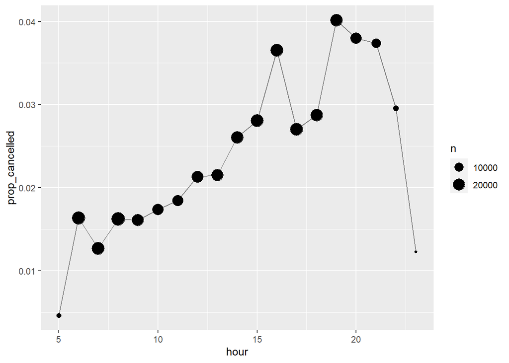

```r
#use dataset flights
flights |>
  #group flights per hour of schedule departure
  group_by(hour = sched_dep_time %/% 100) |>
  #calculate proportion of NAs in dep_time
  summarize(prop_cancelled = mean(is.na(dep_time)),
  #calculate total number of flights
            n = n()) |>
  #filter-out flights schedule for before 1:00
  filter(hour > 1) |>
  #select variables hour and prop_cancelled
  ggplot(aes(x = hour, y = prop_cancelled)) +
  #create lineplot of variables
  geom_line(color = "grey50") +
  #create scatterpoints of variables with size = n
  geom_point(aes(size = n))
```

b) Currently dep_time and sched_dep_time are convenient to look at, but hard to compute with because they’re not really continuous numbers. You can see the basic problem by running the code below: there’s a gap between each hour.

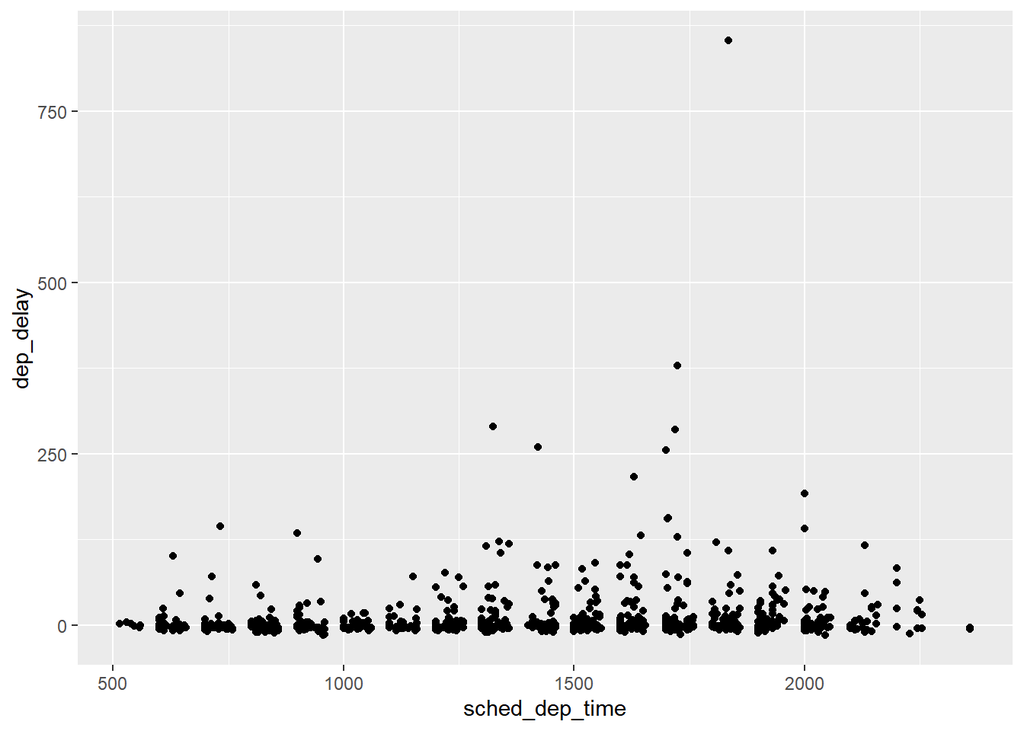

```r
flights |>
  filter(month == 1, day == 1) |>
  ggplot(aes(x = sched_dep_time, y = dep_delay)) +
  geom_point()
```

Convert them to a more truthful representation of time (either fractional hours or minutes since midnight).

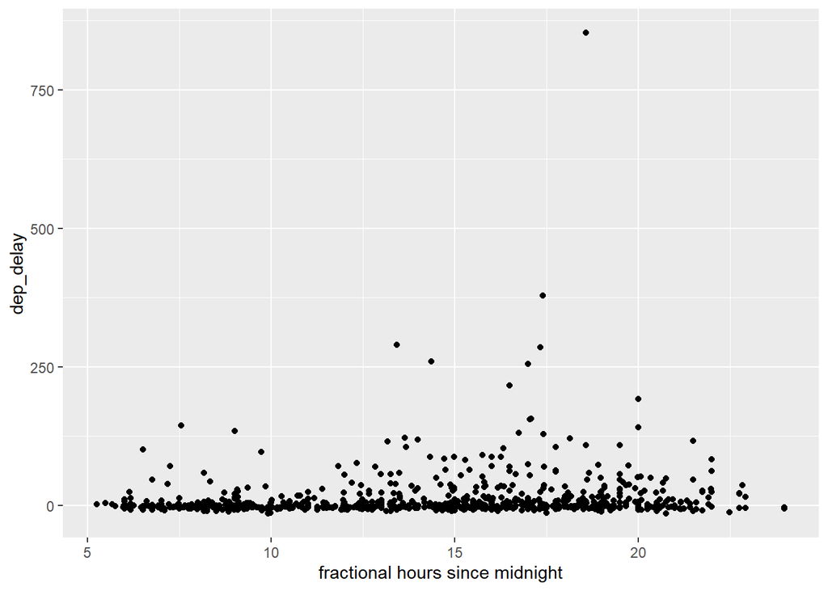

```r
flights |>
  mutate(
    hour = sched_dep_time %/% 100,  #extract hours of schedule departure
    minute = sched_dep_time %% 100, #extract minutes of schedule departure
    time1 = hour + minute/60,       #fractional hours since midnight
#   time1 = hour*60 + minute        #minutes since midnight
  ) |>
  filter(month == 1, day == 1) |>
  ggplot(aes(x = time1, y = dep_delay)) +
  geom_point() +
  labs(x = "fractional hours since midnight")
```

c) Round dep_time and arr_time to the nearest five minutes

```r
flights |>
  mutate(
    #extract hours of departure
    dep_time_hh = dep_time %/% 100,
    #extract minutes of departure in 5min interval
    dep_time_mm = round(dep_time %% 100 / 5) * 5,
    #compute departure time using 5min interval
    dep_time2 = dep_time_hh * 100 + dep_time_mm,
    .keep="used"
  )
```

```
## # A tibble: 336,776 × 4
##    dep_time dep_time_hh dep_time_mm dep_time2
##       <int>       <dbl>       <dbl>     <dbl>
##  1      517           5          15       515
##  2      533           5          35       535
##  3      542           5          40       540
##  4      544           5          45       545
##  5      554           5          55       555
##  6      554           5          55       555
##  7      555           5          55       555
##  8      557           5          55       555
##  9      557           5          55       555
## 10      558           5          60       560
## # ℹ 336,766 more rows
```